# Est_A

Yong Yoon

2022-07-12

# Estimations (Part A)

The general model for estimation is as follows:

$$\begin{align*}
\text{ln } p_{ijk} &= \alpha + \beta DIG_i + \gamma_1 \rho_k +
\gamma_2 \theta_{ij} + \gamma_3 tariff_{ijk} \\
& + \gamma_4 NTM_{ijk}^{Tech} + \gamma_5 NTM_{ijk}^{Non-Tech} +
\gamma_{6i}(NTM_{ijk}^{Tech} \times \delta_i) +
\gamma_{7i}(NTM_{ijk}^{Non-Tech} \times \delta_i) \\
& + \gamma_8 regsim_{ij} + \epsilon_{ijk}
\end{align*}$$

where

| $DIG_i$ | is the average score of separate Pillar measures capturing digital-trade regulation imposed by country $i$ on all imports |
| --- | --- |
| $\rho$ | is the HS6 product fixed effects dummy variable (since regressions are estimated at chapter-level (i.e. there are **96 separate regressions**) |
| $\theta$ | is the pair characteristics (i.e. distance, contiguity, landlocked status, common language, and RTA) |
| $tariff_{ijk}$ | is the applied tariff (MFN or lowest preferential, if available) imposed by $i$ on imports of product $k$ from $j$ |
| $NTM_{ijk}^{Tech}$ | is the count of separate non-tariff measures from chapters A to C imposed by $i$ on imports of product $k$ from $j$ |
| $NTM_{ijk}^{Non-Tech}$ | is the count of separate non-tariff measures from chapters D to O imposed by $i$ on imports of product $k$ from $j$ |
| $regsim_{ij}$ | is a measure of regulatory similarity of country $i$ and $j$ |
| $\delta_{i}$ | is fixed effect of country $i$ (included for interaction with $NTM$) |

# Model 1 (only RDTII & product fixed-effects)

$$\begin{align*}
\text{ln } p_{ijk} &= \alpha + \beta DIG_i + \gamma_2 \rho_k +
\epsilon_{ijk}
\end{align*}$$

```r
library(dplyr)

dta.df <- as.data.frame(cbind(HS_2, results.A, results.B))
colnames(dta.df) <- c('HS2','n','Adj-R2', 'b_dig', 'p')

dta.df$bDig <- with(dta.df, ifelse(p > 0.1, 0, b_dig))
dta.df_ <- as.data.frame(sapply(dta.df, as.numeric))

head(select(dta.df, -b_dig))                 # head(dta.df)
```

```
##   HS2     n            Adj-R2                    p               bDig
## 1  01  1264 0.605763058681538    0.413079095838662                  0
## 2  02  2780 0.536264068200119  0.00451497203207839 -0.305132048580051
## 3  03 12097 0.448004508695748  0.00119041331045086 -0.368264588219247
## 4  04  5067 0.382809309284713    0.104428223624574                  0
## 5  05  1432 0.372829743559505 3.03667575568597e-09                  0
## 6  06  2513  0.57252812534128  0.00041081884360183  0.381833353332323
```

```r
dig_sig.M1 <- nrow(dta.df_[dta.df_$bDig!=0,])
dig_sig.POS.M1 <- nrow(dta.df_[dta.df_$bDig>0,])
dig_sig.NEG.M1 <- nrow(dta.df_[dta.df_$bDig<0,])
Adj_R.avg.M1 <- mean(dta.df_[['Adj-R2']])
```

When considering 96-sectors (at the HS-2 level), we find only 33 digital measure coefficients (of which 17 are positive and 16 are negative) to be significant at the 10 percent level, and the average Adjusted R-square of the regressions is 0.3791892 .

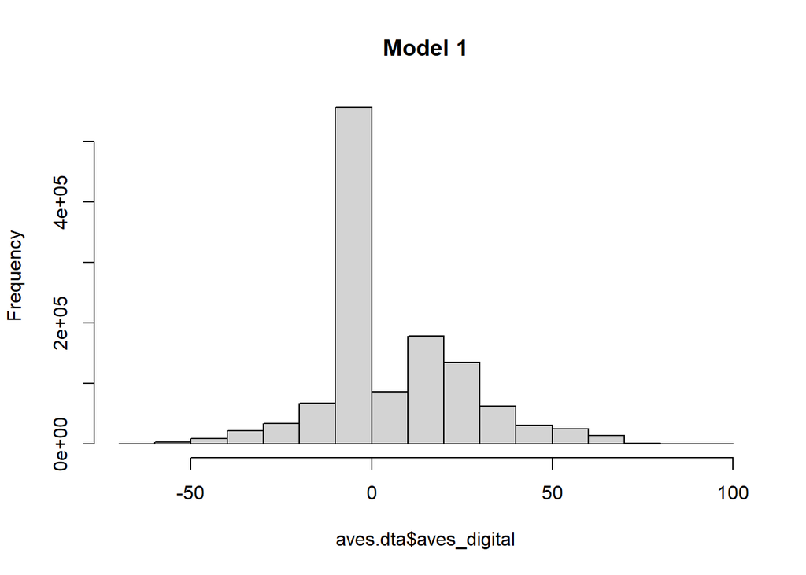

```r
mean(aves.dta$aves_digital, na.rm=TRUE)
```

```
## [1] 7.33411
```

```r
# weighted.mean(aves.dta$aves_digital, aves.dta$tradevalue, na.rm = TRUE)
print(AVES_mean.M1 <- weighted.mean(aves.dta$aves_digital, aves.dta$tradevalue, na.rm = TRUE))
```

```
## [1] -1.529468
```

```r
mean(aves.dta$NNeg, na.rm=TRUE)
```

```
## [1] 10.25318
```

```r
# weighted.mean(aves.dta$NNeg, aves.dta$tradevalue, na.rm = TRUE)
print(AVES_mean_NNeg.M1 <- weighted.mean(aves.dta$NNeg, aves.dta$tradevalue, na.rm = TRUE))
```

```
## [1] 7.917706
```

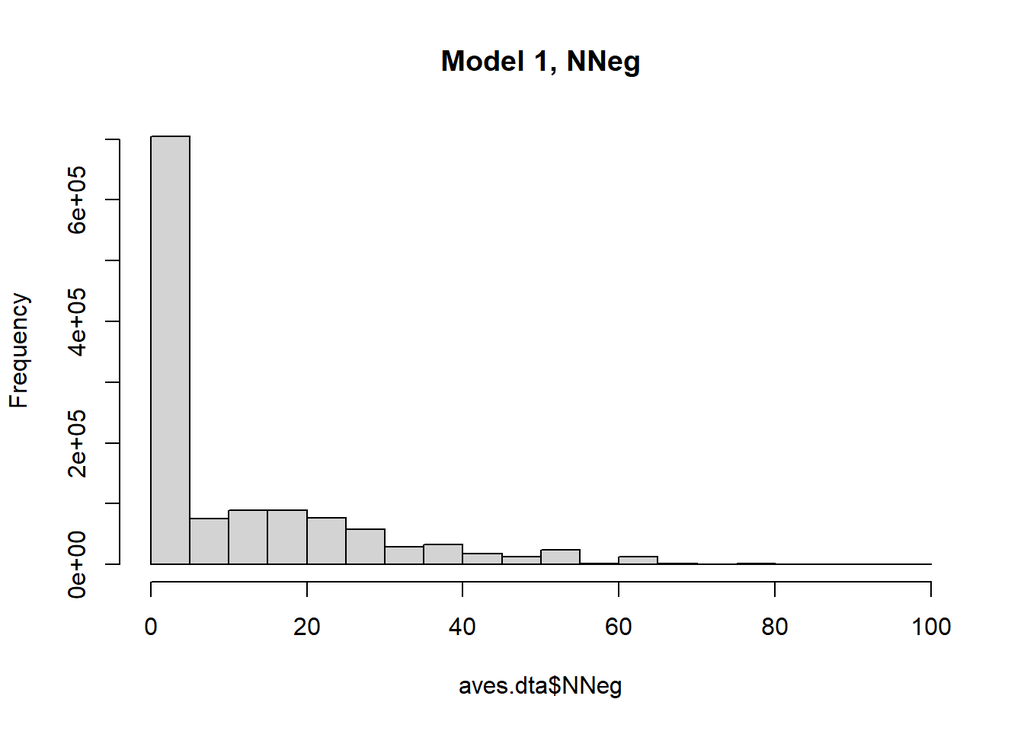

```r
hist(aves.dta$NNeg, main = paste("Model 1, NNeg"))
```

The average weighted (by trade value) of non-negative AVES is 7.9177059 (note: fraction of negative AVES is 0.1541053 ; zero AVES is 0.4102676 and positive AVES is 0.4356271).

# AVE by Country (Model 1)

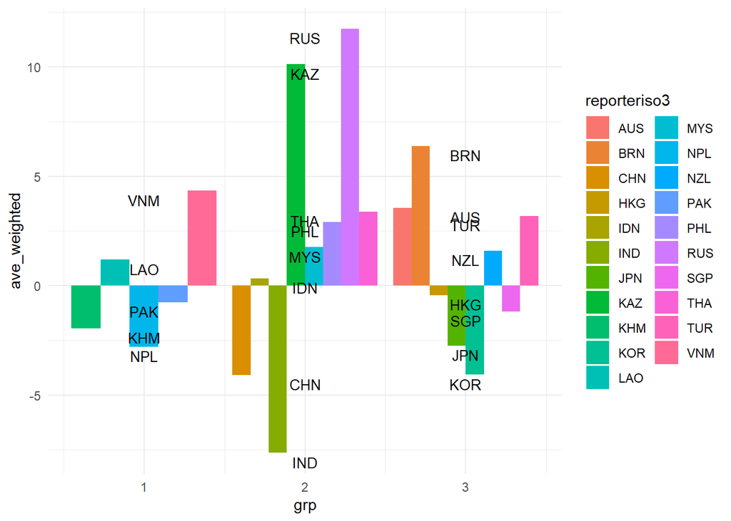

## Model 1 (Truncated)

```
## [1] 9.760012
```

```
## [1] -0.9188339
```

```
## [1] 9.377871
```

```
## [1] 6.638066
```

The average weighted (by trade value) of non-negative AVES is 6.6380657 (note: fraction of negative AVES is 0.0839449 ; zero AVES is 0.4903596 and positive AVES is 0.4256956).

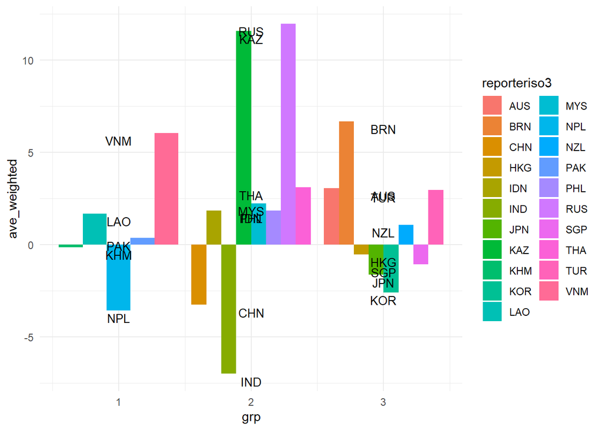

# Model 2 (M1 + gravity model controls)

$$\begin{align*}
\text{ln } p_{ijk} &= \alpha + \beta DIG_i + \gamma_1 \rho_k +
\gamma_2 \theta_{ij} + \gamma_3 tariff_{ijk} + \epsilon_{ijk}
\end{align*}$$

```r
library(dplyr)

dta.df <- as.data.frame(cbind(HS_2, results.A, results.B))
colnames(dta.df) <- c('HS2','n','Adj-R2', 'b_dig', 'p')

dta.df$bDig <- with(dta.df, ifelse(p > 0.1, 0, b_dig))
dta.df_ <- as.data.frame(sapply(dta.df, as.numeric))

head(select(dta.df, -b_dig))                 # head(dta.df)
```

```
##   HS2     n            Adj-R2                    p               bDig
## 1  01  1264 0.630314152020891    0.634253310199952                  0
## 2  02  2780 0.543624158087686   0.0463372213529837 -0.174042255637148
## 3  03 12097   0.4843115831882   0.0805152131440504 -0.186306340249609
## 4  04  5067  0.39773610689895   0.0582930091089156 -0.167266426596354
## 5  05  1432 0.394174045149442 3.12001166105294e-06                  0
## 6  06  2513 0.607651019025779 0.000445056694316885  0.411046050112562
```

```r
dig_sig.M2 <- nrow(dta.df_[dta.df_$bDig!=0,])
dig_sig.POS.M2 <- nrow(dta.df_[dta.df_$bDig>0,])
dig_sig.NEG.M2 <- nrow(dta.df_[dta.df_$bDig<0,])
Adj_R.avg.M2 <- mean(dta.df_[['Adj-R2']])
```

When considering 96-sectors (at the HS-2 level), we find only 33 digital measure coefficients (of which 21 are positive and 12 are negative) to be significant at the 10 percent level, and the average Adjusted R-square of the regressions is 0.4089738 .

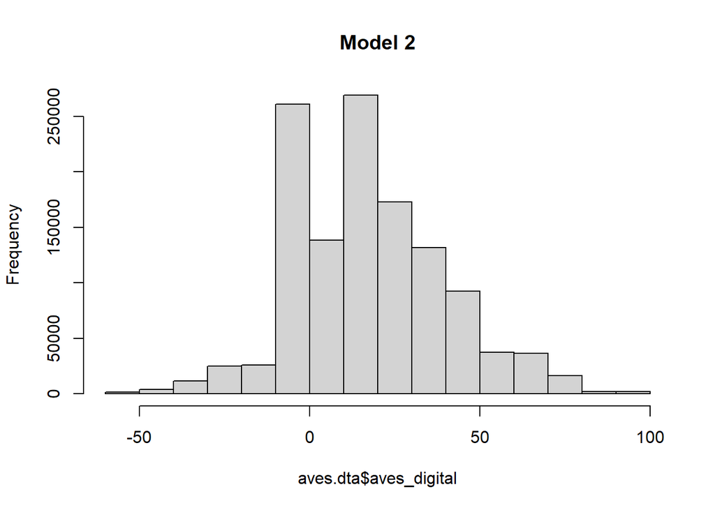

```r
mean(aves.dta$aves_digital, na.rm=TRUE)
```

```
## [1] 18.00131
```

```r
# weighted.mean(aves.dta$aves_digital, aves.dta$tradevalue, na.rm = TRUE)
print(AVES_mean.M2 <- weighted.mean(aves.dta$aves_digital, aves.dta$tradevalue, na.rm = TRUE))
```

```
## [1] 8.299608
```

```r
mean(aves.dta$NNeg, na.rm=TRUE)
```

```
## [1] 19.44763
```

```r
# weighted.mean(aves.dta$NNeg, aves.dta$tradevalue, na.rm = TRUE)
print(AVES_mean_NNeg.M2 <- weighted.mean(aves.dta$NNeg, aves.dta$tradevalue, na.rm = TRUE))
```

```
## [1] 16.10104
```

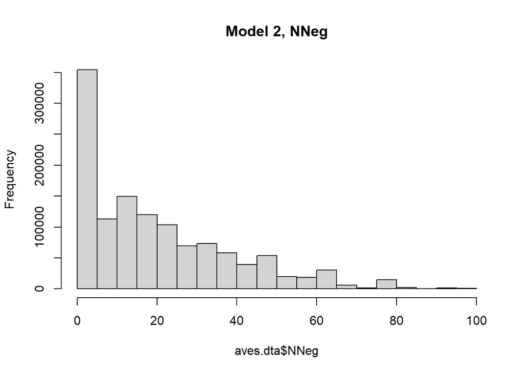

```r
hist(aves.dta$NNeg, main = paste("Model 2, NNeg"))
```

The average weighted (by trade value) of non-negative AVES is 16.1010447 (note: fraction of negative AVES is 0.0716255 ; zero AVES is 0.1959775 and positive AVES is 0.732397).

# AVE by Country (Model 2)

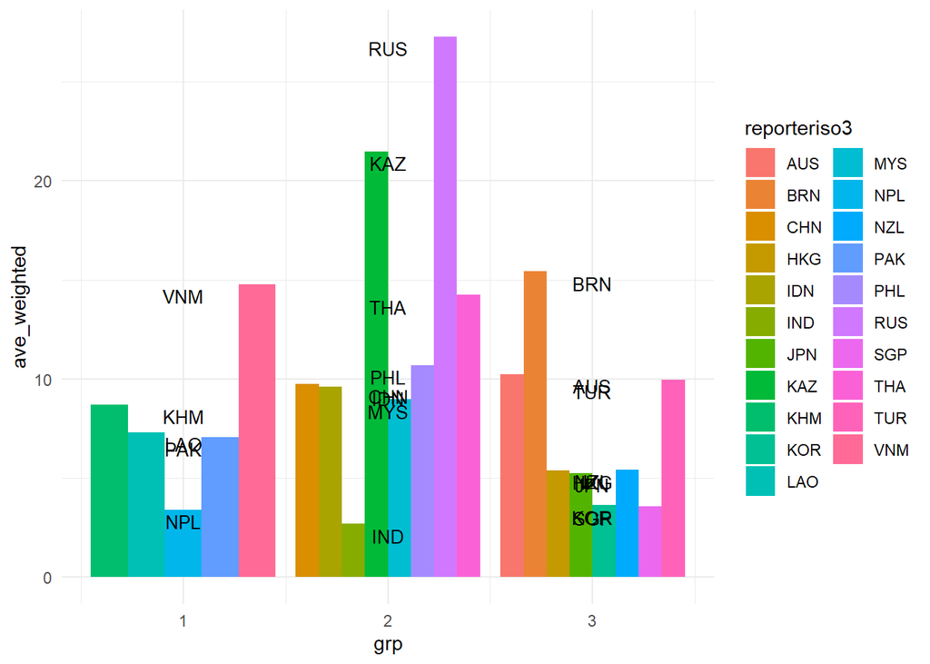

## Model 2 (Truncated)

```
## [1] 18.83677
```

```
## [1] 7.279501
```

```
## [1] 19.00839
```

```
## [1] 13.7317
```

The average weighted (by trade value) of non-negative AVES is 13.731698 (note: fraction of negative AVES is 0.0476073 ; zero AVES is 0.3035741 and positive AVES is 0.6488186).

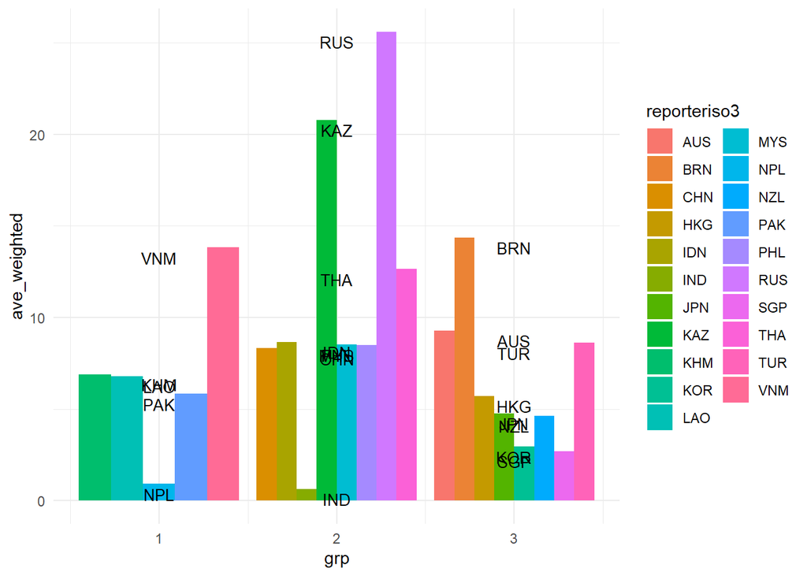

# Model 3 (M2 + NTMs)

$$\begin{align*}
\text{ln } p_{ijk} &= \alpha + \beta DIG_i + \gamma_1 \rho_k +
\gamma_2 \theta_{ij} + \gamma_3 tariff_{ijk} \\
& + \gamma_4 NTM_{ijk}^{Tech} + \gamma_5 NTM_{ijk}^{Non-Tech} +
\epsilon_{ijk}
\end{align*}$$

```r
library(dplyr)

dta.df <- as.data.frame(cbind(HS_2, results.A, results.B))
colnames(dta.df) <- c('HS2','n','Adj-R2', 'b_dig', 'p')

dta.df$bDig <- with(dta.df, ifelse(p > 0.1, 0, b_dig))
dta.df_ <- as.data.frame(sapply(dta.df, as.numeric))

# head(select(dta.df, -b_dig))                 # head(dta.df)

library(DT)
datatable(select(dta.df, -b_dig), filter = 'top', rownames = FALSE)
```

| HS2 | n | Adj-R2 | p | bDig |
| --- | --- | --- | --- | --- |
| 01 | 1264 | 0.630347070309251 | 0.31385575652414 | 0 |
| 02 | 2780 | 0.550358872363434 | 0.0537260003527069 | 0.253897795567187 |
| 03 | 12097 | 0.485892209481486 | 0.974707376210553 | 0 |
| 04 | 5067 | 0.400201794862932 | 0.0508149793344586 | -0.241013898008807 |
| 05 | 1432 | 0.398847150881808 | 0.0068450164769278 | -1.18974068169037 |
| 06 | 2513 | 0.608846076251483 | 0.290797230508686 | 0 |
| 07 | 7686 | 0.418391340609557 | 3.92880203319873e-05 | 0 |
| 08 | 8500 | 0.430213008315106 | 4.10040141008468e-08 | 0 |
| 09 | 7506 | 0.332292059993492 | 0.285344907129242 | 0 |
| 10 | 2032 | 0.40809194081966 | 3.04342130208968e-08 | 0 |

[output cut: 86 more lines]

```r
dig_sig.M3 <- nrow(dta.df_[dta.df_$bDig!=0,])
dig_sig.POS.M3 <- nrow(dta.df_[dta.df_$bDig>0,])
dig_sig.NEG.M3 <- nrow(dta.df_[dta.df_$bDig<0,])
Adj_R.avg.M3 <- mean(dta.df_[['Adj-R2']])
```

When considering 96-sectors (at the HS-2 level), we find only 28 digital measure coefficients (of which 17 are positive and 11 are negative) to be significant at the 10 percent level, and the average Adjusted R-square of the regressions is 0.412071.

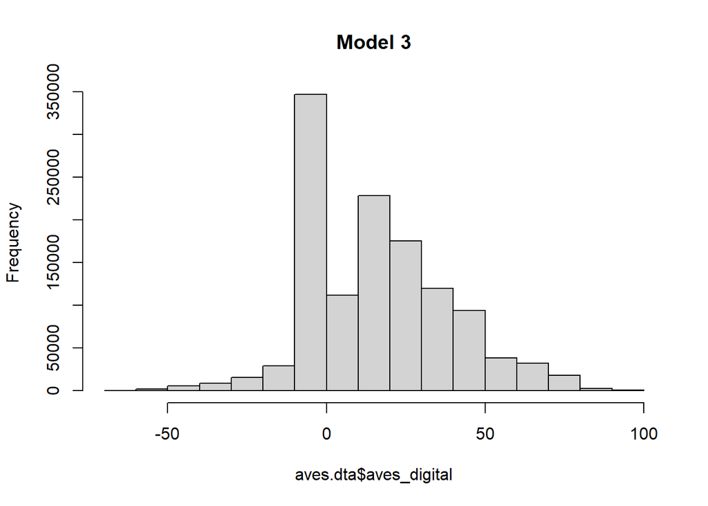

```r
mean(aves.dta$aves_digital, na.rm=TRUE)
```

```
## [1] 16.93826
```

```r
# weighted.mean(aves.dta$aves_digital, aves.dta$tradevalue, na.rm = TRUE)
print(AVES_mean.M3 <- weighted.mean(aves.dta$aves_digital, aves.dta$tradevalue, na.rm = TRUE))
```

```
## [1] 9.355794
```

```r
mean(aves.dta$NNeg, na.rm=TRUE)
```

```
## [1] 18.24215
```

```r
# weighted.mean(aves.dta$NNeg, aves.dta$tradevalue, na.rm = TRUE)
print(AVES_mean_NNeg.M3 <- weighted.mean(aves.dta$NNeg, aves.dta$tradevalue, na.rm = TRUE))
```

```
## [1] 15.18099
```

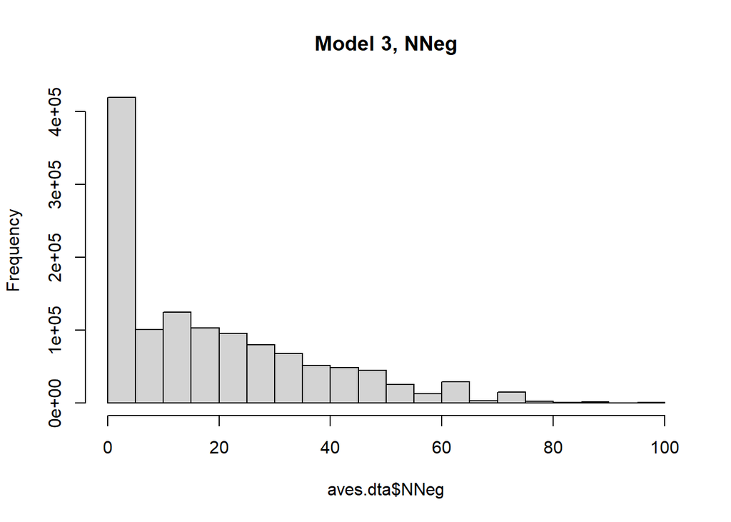

```r
hist(aves.dta$NNeg, main = paste("Model 3, NNeg"))
```

The average weighted (by trade value) of non-negative AVES is 15.1809915 (note: fraction of negative AVES is 0.061575 ; zero AVES is 0.270666 and positive AVES is 0.667759).

# AVE by Country (Model 3)

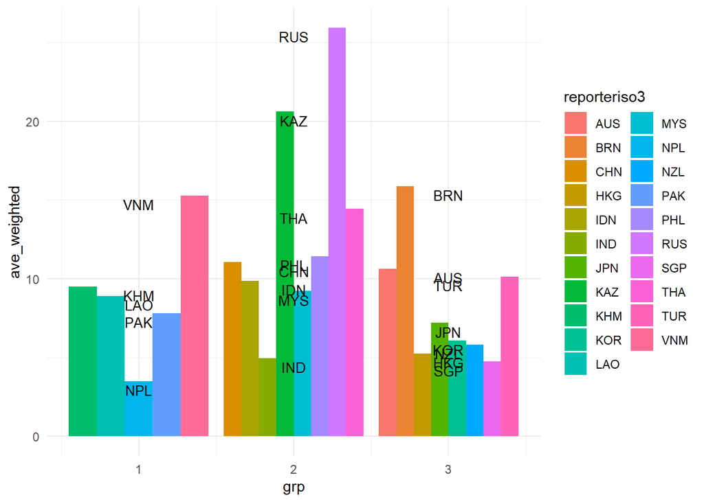

## Model 3 (Truncated)

```
## [1] 18.10763
```

```
## [1] 9.118859
```

```
## [1] 17.84286
```

```
## [1] 13.40735
```

The average weighted (by trade value) of non-negative AVES is 13.407348 (note: fraction of negative AVES is 0.0398363 ; zero AVES is 0.3389231 and positive AVES is 0.6212406).

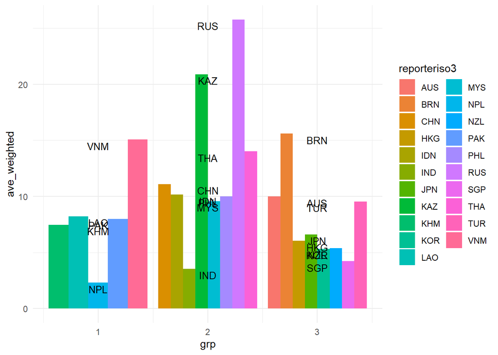

## Model 3 + regulatory similarity

$$\begin{align*}
\text{ln } p_{ijk} &= \alpha + \beta DIG_i + \gamma_1 \rho_k +
\gamma_2 \theta_{ij} + \gamma_3 tariff_{ijk} \\
& + \gamma_4 NTM_{ijk}^{Tech} + \gamma_5 NTM_{ijk}^{Non-Tech} \\
& + \gamma_6 regsim_{ij} + \epsilon_{ijk}
\end{align*}$$

```r
library(dplyr)

dta.df <- as.data.frame(cbind(HS_2, results.A, results.B))
colnames(dta.df) <- c('HS2','n','Adj-R2', 'b_dig', 'p')

dta.df$bDig <- with(dta.df, ifelse(p > 0.1, 0, b_dig))
dta.df_ <- as.data.frame(sapply(dta.df, as.numeric))

head(select(dta.df, -b_dig))                 # head(dta.df)
```

```
##   HS2    n            Adj-R2                 p bDig
## 1  01  347 0.569658191589087 0.426775464356336    0
## 2  02  946 0.463481100692357 0.730180421510811    0
## 3  03 5798 0.443274221570381 0.944551299711905    0
## 4  04 1681 0.396276705413283 0.161195739512862    0
## 5  05  565 0.327132952140953 0.122333749079066    0
## 6  06  849 0.547543708247916 0.749191628291178    0
```

```r
dig_sig.M3_ <- nrow(dta.df_[dta.df_$bDig!=0,])
dig_sig.POS.M3_ <- nrow(dta.df_[dta.df_$bDig>0,])
dig_sig.NEG.M3_ <- nrow(dta.df_[dta.df_$bDig<0,])
Adj_R.avg.M3_ <- mean(dta.df_[['Adj-R2']])
```

When considering 96-sectors (at the HS-2 level), we find only 36 digital measure coefficients (of which 26 are positive and 10 are negative) to be significant at the 10 percent level, and the average Adjusted R-square of the regressions is 0.3865028.

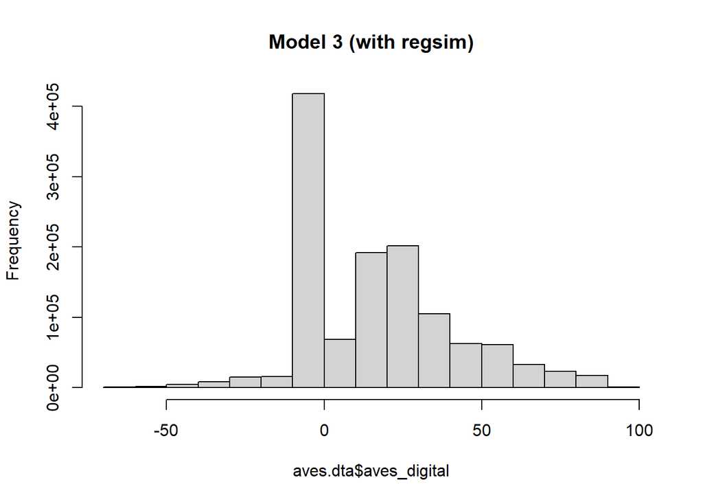

```r
aves.dta <- read.csv(paste0(path_, "aves_", model, ".csv"))
hist(aves.dta$aves_digital, main = paste("Model 3 (with regsim)"))
```

```r
# weighted.mean(aves.dta$aves_digital, aves.dta$tradevalue, na.rm = TRUE)
```

```r
aves.dta$NNeg <- ifelse(aves.dta$aves_digital<0,0,aves.dta$aves_digital)
# class(aves.dta$POS)
mean(aves.dta$aves_digital, na.rm=TRUE)
```

```
## [1] 18.11009
```

```r
# weighted.mean(aves.dta$aves_digital, aves.dta$tradevalue, na.rm = TRUE)
print(AVES_mean.M3_ <- weighted.mean(aves.dta$aves_digital, aves.dta$tradevalue, na.rm = TRUE))
```

```
## [1] 8.970609
```

```r
mean(aves.dta$NNeg, na.rm=TRUE)
```

```
## [1] 19.12456
```

```r
print(AVES_mean_NNeg.M3_ <- weighted.mean(aves.dta$NNeg, aves.dta$tradevalue, na.rm = TRUE))
```

```
## [1] 16.06243
```

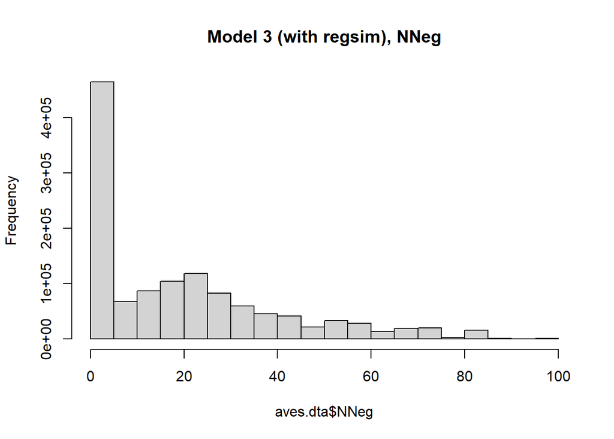

```r
hist(aves.dta$NNeg, main = paste("Model 3 (with regsim), NNeg"))
```

The average weighted (by trade value) of non-negative AVES is 16.0624332 (note: fraction of negative AVES is 0.0398363 ; zero AVES is 0.3375476 and positive AVES is 0.6226162).

## AVE by Country (Model 3 + regsim)

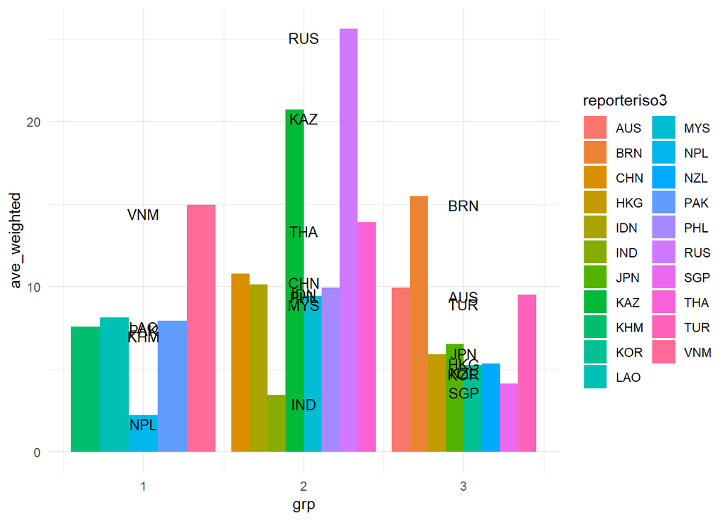

# Model 4 (M3 + NTM_Interactions)

$$\begin{align*}
\text{ln } p_{ijk} &= \alpha + \beta DIG_i + \gamma_1 \rho_k +
\gamma_2 \theta_{ij} + \gamma_3 tariff_{ijk} \\
& + \gamma_4 NTM_{ijk}^{Tech} + \gamma_5 NTM_{ijk}^{Non-Tech} +
\gamma_{6i}(NTM_{ijk}^{Tech} \times \delta_i) +
\gamma_{7i}(NTM_{ijk}^{Non-Tech} \times \delta_i) + \epsilon_{ijk}
\end{align*}$$

```r
library(dplyr)

dta.df <- as.data.frame(cbind(HS_2, results.A, results.B))
colnames(dta.df) <- c('HS2','n','Adj-R2', 'b_dig', 'p')

dta.df$bDig <- with(dta.df, ifelse(p > 0.1, 0, b_dig))
dta.df_ <- as.data.frame(sapply(dta.df, as.numeric))

head(select(dta.df, -b_dig))                 # head(dta.df)
```

```
##   HS2     n            Adj-R2                  p              bDig
## 1  01  1264 0.646113737576309  0.361143859715313                 0
## 2  02  2780 0.601296053962438  0.191613043410495                 0
## 3  03 12097 0.512160944107661 0.0434313203743901 0.895051953210204
## 4  04  5067 0.442215491672954  0.780460882009972                 0
## 5  05  1432  0.50871117385069  0.203035473247691                 0
## 6  06  2513 0.636821215978973  0.736198423549308                 0
```

```r
dig_sig.M4 <- nrow(dta.df_[dta.df_$bDig!=0,])
dig_sig.POS.M4 <- nrow(dta.df_[dta.df_$bDig>0,])
dig_sig.NEG.M4 <- nrow(dta.df_[dta.df_$bDig<0,])
Adj_R.avg.M4 <- mean(dta.df_[['Adj-R2']])
```

When considering 96-sectors (at the HS-2 level), we find only 32 digital measure coefficients (of which 21 are positive and 11 are negative) to be significant at the 10 percent level, and the average Adjusted R-square of the regressions is 0.4450487 .

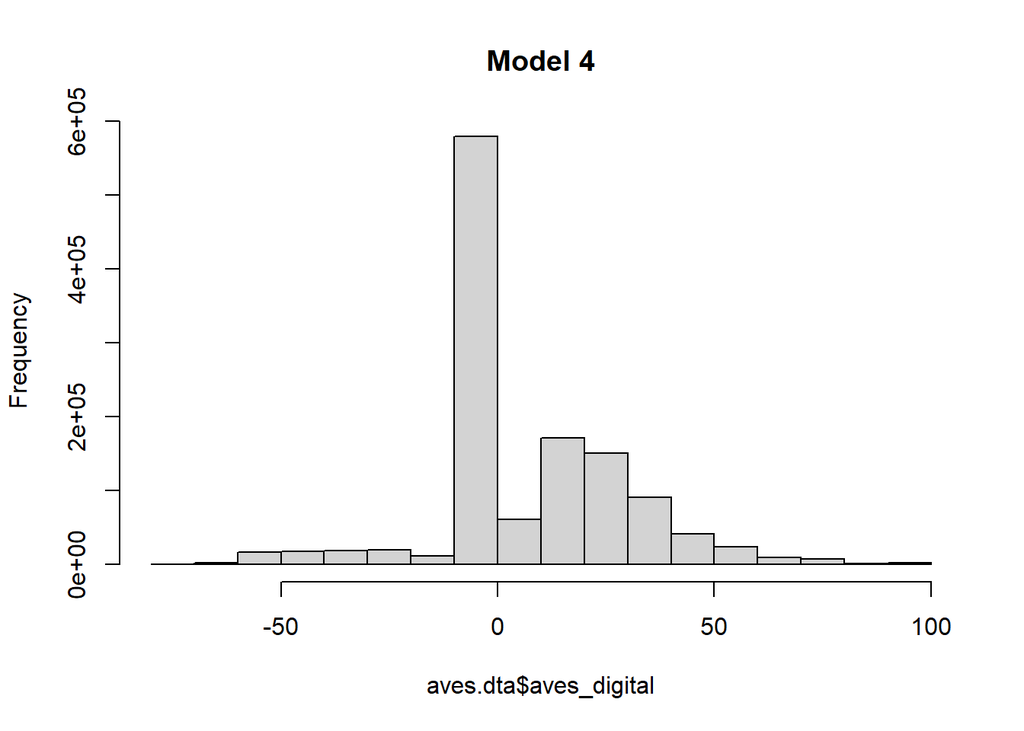

```r
mean(aves.dta$aves_digital, na.rm=TRUE)
```

```
## [1] 9.257171
```

```r
# weighted.mean(aves.dta$aves_digital, aves.dta$tradevalue, na.rm = TRUE)
print(AVES_mean.M4 <- weighted.mean(aves.dta$aves_digital, aves.dta$tradevalue, na.rm = TRUE))
```

```
## [1] 3.028045
```

```r
mean(aves.dta$NNeg, na.rm=TRUE)
```

```
## [1] 11.89976
```

```r
# weighted.mean(aves.dta$NNeg, aves.dta$tradevalue, na.rm = TRUE)
print(AVES_mean_NNeg.M4 <- weighted.mean(aves.dta$NNeg, aves.dta$tradevalue, na.rm = TRUE))
```

```
## [1] 7.308713
```

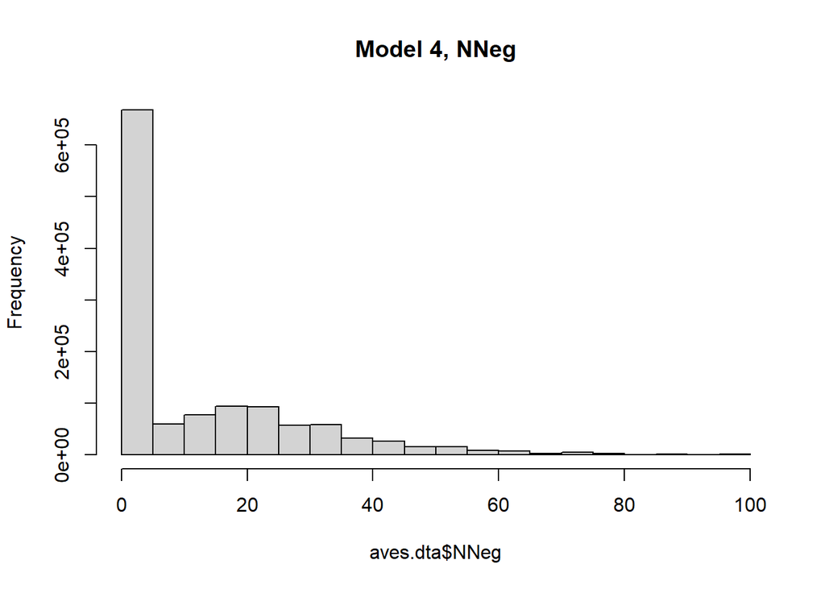

```r
hist(aves.dta$NNeg, main = paste("Model 4, NNeg"))
```

The average weighted (by trade value) of non-negative AVES is 7.3087128 (note: fraction of negative AVES is 0.0726166 ; zero AVES is 0.4700216 and positive AVES is 0.4573618).

# AVE by Country (Model 4)

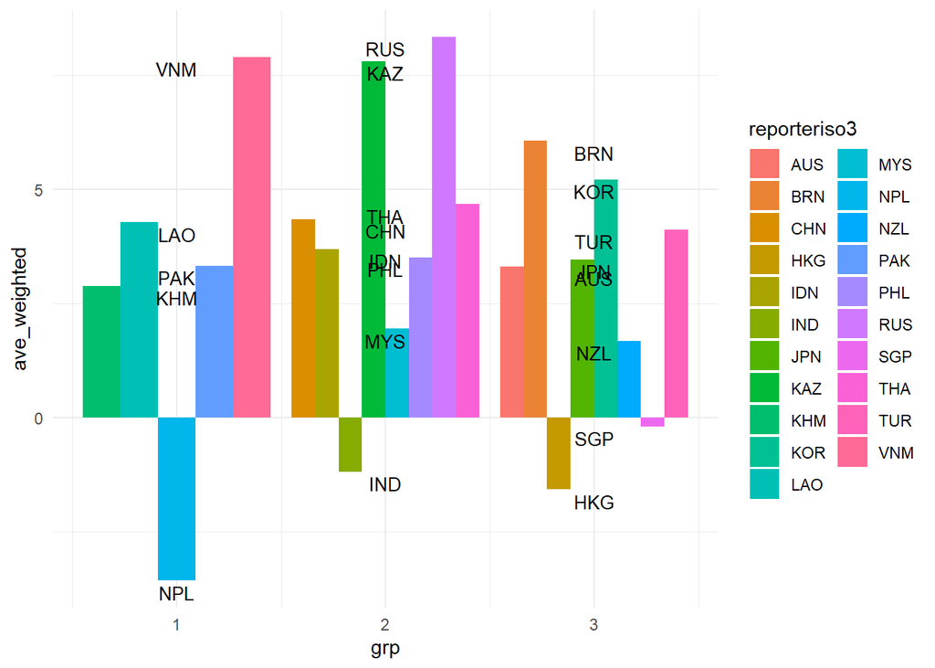

## Model 4 (Truncated)

```
## [1] 7.029607
```

```
## [1] 0.1060412
```

```
## [1] 11.2901
```

```
## [1] 5.904402
```

The average weighted (by trade value) of non-negative AVES is 5.9044024 (note: fraction of negative AVES is 0.0632942 ; zero AVES is 0.5750203 and positive AVES is 0.3616855).

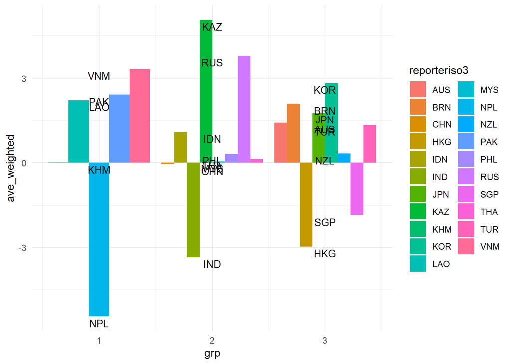

# Model 5 (M4 + regulatory similarity)

$$\begin{align*}
\text{ln } p_{ijk} &= \alpha + \beta DIG_i + \gamma_1 \rho_k +
\gamma_2 \theta_{ij} + \gamma_3 tariff_{ijk} \\
& + \gamma_4 NTM_{ijk}^{Tech} + \gamma_5 NTM_{ijk}^{Non-Tech} +
\gamma_{6i}(NTM_{ijk}^{Tech} \times \delta_i) +
\gamma_{7i}(NTM_{ijk}^{Non-Tech} \times \delta_i) \\
& + \gamma_8 regsim_{ij} + \epsilon_{ijk}
\end{align*}$$

```r
library(dplyr)

dta.df <- as.data.frame(cbind(HS_2, results.A, results.B))
colnames(dta.df) <- c('HS2','n','Adj-R2', 'b_dig', 'p')

dta.df$bDig <- with(dta.df, ifelse(p > 0.1, 0, b_dig))
dta.df_ <- as.data.frame(sapply(dta.df, as.numeric))

# head(select(dta.df, -b_dig))                 # head(dta.df)

library(DT)
datatable(select(dta.df, -b_dig), filter = 'top', rownames = FALSE)
```

| HS2 | n | Adj-R2 | p | bDig |
| --- | --- | --- | --- | --- |
| 01 | 347 | 0.61098772690828 | 0.81745131204636 | 0 |
| 02 | 946 | 0.504790901976494 | 0.526375790707506 | 0 |
| 03 | 5798 | 0.477613039009289 | 0.209034650840436 | 0 |
| 04 | 1681 | 0.434379694583005 | 0.305417190003204 | 0 |
| 05 | 565 | 0.39143208536494 | 0.254042692680288 | 0 |
| 06 | 849 | 0.584339481483768 | 0.0352699885986907 | -1.34736757687022 |
| 07 | 3493 | 0.470799331432179 | 0.000278161163783002 | -1.70400894191302 |
| 08 | 3459 | 0.480172979421738 | 0.00308619011766475 | -1.92750829582966 |
| 09 | 3233 | 0.363265202648051 | 0.972579650444241 | 0 |
| 10 | 900 | 0.421575505373243 | 7.70947445040333e-08 | 0 |

[output cut: 86 more lines]

```r
dig_sig.M5 <- nrow(dta.df_[dta.df_$bDig!=0,])
dig_sig.POS.M5 <- nrow(dta.df_[dta.df_$bDig>0,])
dig_sig.NEG.M5 <- nrow(dta.df_[dta.df_$bDig<0,])
Adj_R.avg.M5 <- mean(dta.df_[['Adj-R2']])
```

When considering 96-sectors (at the HS-2 level), we find only 35 digital measure coefficients (of which 22 are positive and 13 are negative) to be significant at the 10 percent level, and the average Adjusted R-square of the regressions is 0.4237376 .

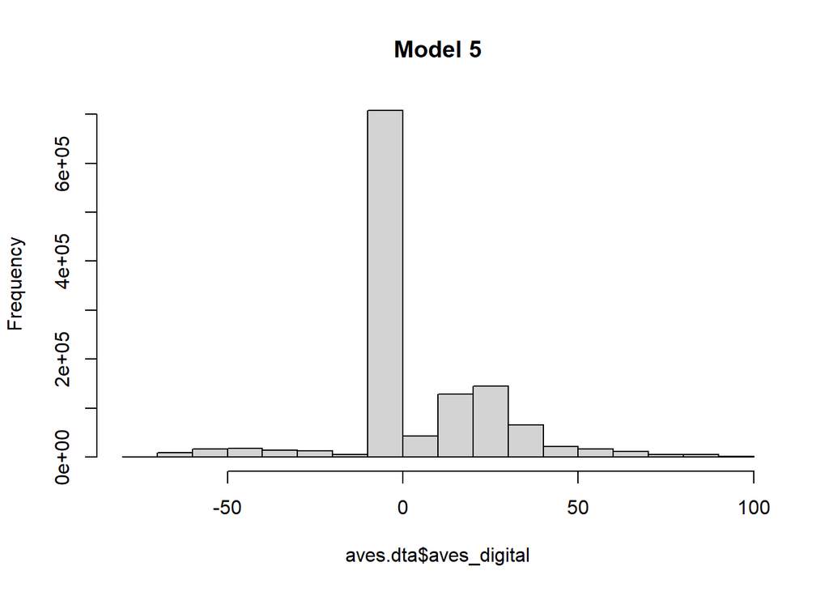

```r
aves.dta <- read.csv(paste0(path_, "aves_", model, ".csv"))
aves.dta$NNeg <- ifelse(aves.dta$aves_digital<0,0,aves.dta$aves_digital)
# class(aves.dta$NNEg)

hist(aves.dta$aves_digital, main = paste("Model 5"))
```

```r
# weighted.mean(aves.dta$aves_digital, aves.dta$tradevalue, na.rm = TRUE)
```

```r
mean(aves.dta$aves_digital, na.rm=TRUE)
```

```
## [1] 6.923642
```

```r
# weighted.mean(aves.dta$aves_digital, aves.dta$tradevalue, na.rm = TRUE)
print(AVES_mean.M5 <- weighted.mean(aves.dta$aves_digital, aves.dta$tradevalue, na.rm = TRUE))
```

```
## [1] 0.07431188
```

```r
mean(aves.dta$NNeg, na.rm=TRUE)
```

```
## [1] 9.563147
```

```r
# weighted.mean(aves.dta$NNeg, aves.dta$tradevalue, na.rm = TRUE)
print(AVES_mean_NNeg.M5 <- weighted.mean(aves.dta$NNeg, aves.dta$tradevalue, na.rm = TRUE))
```

```
## [1] 4.719376
```

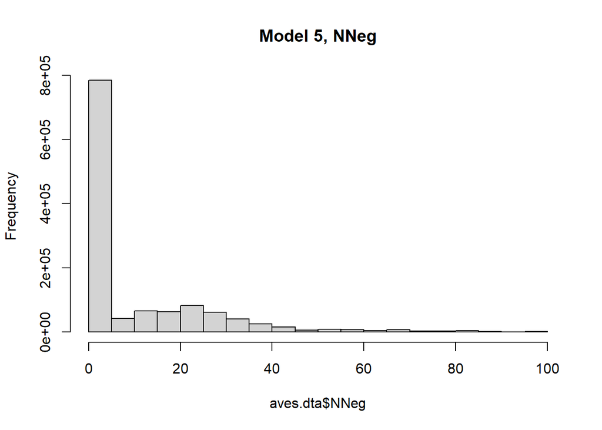

```r
hist(aves.dta$NNeg, main = paste("Model 5, NNeg"))
```

The average weighted (by trade value) of non-negative AVES is 4.7193755 (note: fraction of negative AVES is 0.0632942 ; zero AVES is 0.5750203 and positive AVES is 0.3616855).

# AVE by Country (Model 5)

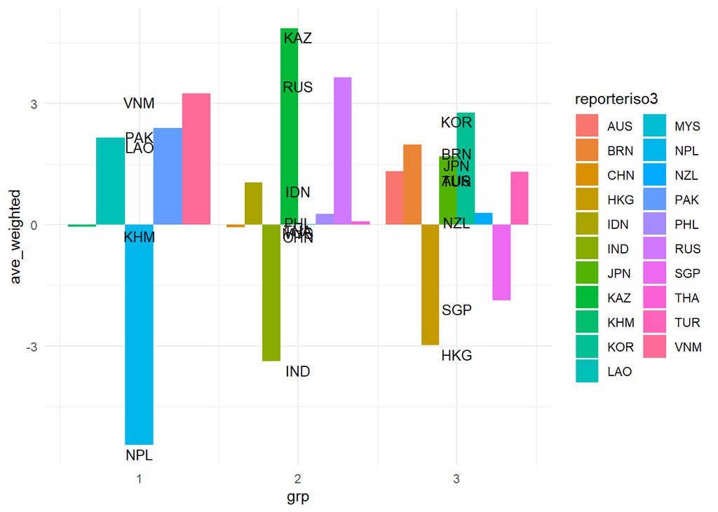

# Summary of AVES

|  | Weighted mean of Non-negative AVEs | Weighted mean of AVEs |
| --- | --- | --- |
| Model 1 | 7.9177059 | -1.5294682 |
| Model 1 (T) | 6.6380657 | -0.9188339 |
| Model 2 | 16.1010447 | 8.2996082 |
| Model 2 (T) | 13.731698 | 7.2795006 |
| Model 3 | 15.1809915 | 9.355794 |
| Model 3 (T) | 13.407348 | 9.118859 |
| Model 3 (+ regsim) | 16.0624332 | 8.9706094 |
| Model 4 | 7.3087128 | 3.0280449 |
| Model 4 (T) | 5.9044024 | 0.1060412 |
| Model 5 | 4.7193755 | 0.0743119 |